# sqldf examples

Today we will take a look at:

1. the iris data
2. the diamonds data in the *ggplot2* library
3. the gapminder data in the *gapminder* library
4. the nycflights13 data in the *nyclights13* library

A good website to look at to learn more about sql is [w3school.com](https://www.w3schools.com/sql/default.asp)

And a good book is [Select * SQL](https://selectstarsql.com/).

Finally, check out [data.world](https://data.world/)

This is an updated version of my SQL Examples R Notebook using the *tidyverse* and *sqldf*.

```r
library(ggplot2)
library(gapminder)
library(nycflights13)
library(tidyverse)
library(sqldf)
library(skimr)
library(kableExtra)
```

```r
iris %>% head()
```

|  | Sepal.Length | Sepal.Width | Petal.Length | Petal.Width | Species |
| --- | --- | --- | --- | --- | --- |
| 1 | 5.1 | 3.5 | 1.4 | 0.2 | setosa |
| 2 | 4.9 | 3.0 | 1.4 | 0.2 | setosa |
| 3 | 4.7 | 3.2 | 1.3 | 0.2 | setosa |
| 4 | 4.6 | 3.1 | 1.5 | 0.2 | setosa |
| 5 | 5.0 | 3.6 | 1.4 | 0.2 | setosa |
| 6 | 5.4 | 3.9 | 1.7 | 0.4 | setosa |

```r
head(diamonds)
```

| carat | cut | color | clarity | depth | table | price | x | y | z |
| --- | --- | --- | --- | --- | --- | --- | --- | --- | --- |
| 0.23 | Ideal | E | SI2 | 61.5 | 55 | 326 | 3.95 | 3.98 | 2.43 |
| 0.21 | Premium | E | SI1 | 59.8 | 61 | 326 | 3.89 | 3.84 | 2.31 |
| 0.23 | Good | E | VS1 | 56.9 | 65 | 327 | 4.05 | 4.07 | 2.31 |
| 0.29 | Premium | I | VS2 | 62.4 | 58 | 334 | 4.20 | 4.23 | 2.63 |
| 0.31 | Good | J | SI2 | 63.3 | 58 | 335 | 4.34 | 4.35 | 2.75 |
| 0.24 | Very Good | J | VVS2 | 62.8 | 57 | 336 | 3.94 | 3.96 | 2.48 |

```r
gapminder %>% head()
```

| country | continent | year | lifeExp | pop | gdpPercap |
| --- | --- | --- | --- | --- | --- |
| Afghanistan | Asia | 1952 | 28.801 | 8425333 | 779.4453 |
| Afghanistan | Asia | 1957 | 30.332 | 9240934 | 820.8530 |
| Afghanistan | Asia | 1962 | 31.997 | 10267083 | 853.1007 |
| Afghanistan | Asia | 1967 | 34.020 | 11537966 | 836.1971 |
| Afghanistan | Asia | 1972 | 36.088 | 13079460 | 739.9811 |
| Afghanistan | Asia | 1977 | 38.438 | 14880372 | 786.1134 |

```r
airlines %>% head() %>% kable() %>% kable_styling()
```

| carrier | name |
| --- | --- |
| 9E | Endeavor Air Inc. |
| AA | American Airlines Inc. |
| AS | Alaska Airlines Inc. |
| B6 | JetBlue Airways |
| DL | Delta Air Lines Inc. |
| EV | ExpressJet Airlines Inc. |

```r
flights %>% head()
```

| year | month | day | dep_time | sched_dep_time | dep_delay | arr_time | sched_arr_time | arr_delay | carrier | flight | tailnum | origin | dest | air_time | distance | hour | minute | time_hour |
| --- | --- | --- | --- | --- | --- | --- | --- | --- | --- | --- | --- | --- | --- | --- | --- | --- | --- | --- |
| 2013 | 1 | 1 | 517 | 515 | 2 | 830 | 819 | 11 | UA | 1545 | N14228 | EWR | IAH | 227 | 1400 | 5 | 15 | 2013-01-01 05:00:00 |
| 2013 | 1 | 1 | 533 | 529 | 4 | 850 | 830 | 20 | UA | 1714 | N24211 | LGA | IAH | 227 | 1416 | 5 | 29 | 2013-01-01 05:00:00 |
| 2013 | 1 | 1 | 542 | 540 | 2 | 923 | 850 | 33 | AA | 1141 | N619AA | JFK | MIA | 160 | 1089 | 5 | 40 | 2013-01-01 05:00:00 |
| 2013 | 1 | 1 | 544 | 545 | -1 | 1004 | 1022 | -18 | B6 | 725 | N804JB | JFK | BQN | 183 | 1576 | 5 | 45 | 2013-01-01 05:00:00 |
| 2013 | 1 | 1 | 554 | 600 | -6 | 812 | 837 | -25 | DL | 461 | N668DN | LGA | ATL | 116 | 762 | 6 | 0 | 2013-01-01 06:00:00 |
| 2013 | 1 | 1 | 554 | 558 | -4 | 740 | 728 | 12 | UA | 1696 | N39463 | EWR | ORD | 150 | 719 | 5 | 58 | 2013-01-01 05:00:00 |

```r
planes %>% head()
```

| tailnum | year | type | manufacturer | model | engines | seats | speed | engine |
| --- | --- | --- | --- | --- | --- | --- | --- | --- |
| N10156 | 2004 | Fixed wing multi engine | EMBRAER | EMB-145XR | 2 | 55 | NA | Turbo-fan |
| N102UW | 1998 | Fixed wing multi engine | AIRBUS INDUSTRIE | A320-214 | 2 | 182 | NA | Turbo-fan |
| N103US | 1999 | Fixed wing multi engine | AIRBUS INDUSTRIE | A320-214 | 2 | 182 | NA | Turbo-fan |
| N104UW | 1999 | Fixed wing multi engine | AIRBUS INDUSTRIE | A320-214 | 2 | 182 | NA | Turbo-fan |
| N10575 | 2002 | Fixed wing multi engine | EMBRAER | EMB-145LR | 2 | 55 | NA | Turbo-fan |
| N105UW | 1999 | Fixed wing multi engine | AIRBUS INDUSTRIE | A320-214 | 2 | 182 | NA | Turbo-fan |

```r
weather %>% head()
```

| origin | year | month | day | hour | temp | dewp | humid | wind_dir | wind_speed | wind_gust | precip | pressure | visib | time_hour |
| --- | --- | --- | --- | --- | --- | --- | --- | --- | --- | --- | --- | --- | --- | --- |
| EWR | 2013 | 1 | 1 | 0 | 37.04 | 21.92 | 53.97 | 230 | 10.35702 | 11.91865 | 0 | 1013.9 | 10 | 2012-12-31 16:00:00 |
| EWR | 2013 | 1 | 1 | 1 | 37.04 | 21.92 | 53.97 | 230 | 13.80936 | 15.89154 | 0 | 1013.0 | 10 | 2012-12-31 17:00:00 |
| EWR | 2013 | 1 | 1 | 2 | 37.94 | 21.92 | 52.09 | 230 | 12.65858 | 14.56724 | 0 | 1012.6 | 10 | 2012-12-31 18:00:00 |
| EWR | 2013 | 1 | 1 | 3 | 37.94 | 23.00 | 54.51 | 230 | 13.80936 | 15.89154 | 0 | 1012.7 | 10 | 2012-12-31 19:00:00 |
| EWR | 2013 | 1 | 1 | 4 | 37.94 | 24.08 | 57.04 | 240 | 14.96014 | 17.21583 | 0 | 1012.8 | 10 | 2012-12-31 20:00:00 |
| EWR | 2013 | 1 | 1 | 6 | 39.02 | 26.06 | 59.37 | 270 | 10.35702 | 11.91865 | 0 | 1012.0 | 10 | 2012-12-31 22:00:00 |

1. Look at the iris data.

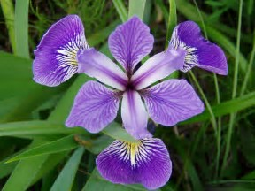

```r
knitr::include_graphics("E:/University/classes/2016-2017/Spring2017/Stat6620/sqldf/thUFAY9IC0.jpg")
```

```r
iris %>% glimpse()
```

```
Observations: 150
Variables: 5
$ Sepal.Length <dbl> 5.1, 4.9, 4.7, 4.6, 5.0, 5.4, 4.6, 5.0, 4.4, 4.9, 5.4, 4.8, 4.8, 4.3, 5.8, 5.7, 5.4, 5.1, 5.7, 5.1, 5.4, 5.1, ...
$ Sepal.Width  <dbl> 3.5, 3.0, 3.2, 3.1, 3.6, 3.9, 3.4, 3.4, 2.9, 3.1, 3.7, 3.4, 3.0, 3.0, 4.0, 4.4, 3.9, 3.5, 3.8, 3.8, 3.4, 3.7, ...
$ Petal.Length <dbl> 1.4, 1.4, 1.3, 1.5, 1.4, 1.7, 1.4, 1.5, 1.4, 1.5, 1.5, 1.6, 1.4, 1.1, 1.2, 1.5, 1.3, 1.4, 1.7, 1.5, 1.7, 1.5, ...
$ Petal.Width  <dbl> 0.2, 0.2, 0.2, 0.2, 0.2, 0.4, 0.3, 0.2, 0.2, 0.1, 0.2, 0.2, 0.1, 0.1, 0.2, 0.4, 0.4, 0.3, 0.3, 0.3, 0.2, 0.4, ...
$ Species      <fct> setosa, setosa, setosa, setosa, setosa, setosa, setosa, setosa, setosa, setosa, setosa, setosa, setosa, setosa...
```

```r
species.means <- with(iris, aggregate(iris[-5], by=list(Species), FUN=mean, na.rm=TRUE))
print(species.means)
```

| Group.1 | Sepal.Length | Sepal.Width | Petal.Length | Petal.Width |
| --- | --- | --- | --- | --- |
| setosa | 5.006 | 3.428 | 1.462 | 0.246 |
| versicolor | 5.936 | 2.770 | 4.260 | 1.326 |
| virginica | 6.588 | 2.974 | 5.552 | 2.026 |

2. Start by looking at the **diamond** data.

Here is a very nice blog post about using **sqldf**.

https://www.r-bloggers.com/manipulating-data-frames-using-sqldf-a-brief-overview/

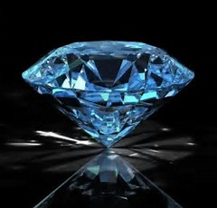

```r
knitr::include_graphics("E:/University/classes/2016-2017/Spring2017/Stat6620/sqldf/diamond.png")
```

```r
data("diamonds")
head(diamonds)
```

| carat | cut | color | clarity | depth | table | price | x | y | z |
| --- | --- | --- | --- | --- | --- | --- | --- | --- | --- |
| 0.23 | Ideal | E | SI2 | 61.5 | 55 | 326 | 3.95 | 3.98 | 2.43 |
| 0.21 | Premium | E | SI1 | 59.8 | 61 | 326 | 3.89 | 3.84 | 2.31 |
| 0.23 | Good | E | VS1 | 56.9 | 65 | 327 | 4.05 | 4.07 | 2.31 |
| 0.29 | Premium | I | VS2 | 62.4 | 58 | 334 | 4.20 | 4.23 | 2.63 |
| 0.31 | Good | J | SI2 | 63.3 | 58 | 335 | 4.34 | 4.35 | 2.75 |
| 0.24 | Very Good | J | VVS2 | 62.8 | 57 | 336 | 3.94 | 3.96 | 2.48 |

```r
tail(diamonds)
```

| carat | cut | color | clarity | depth | table | price | x | y | z |
| --- | --- | --- | --- | --- | --- | --- | --- | --- | --- |
| 0.72 | Premium | D | SI1 | 62.7 | 59 | 2757 | 5.69 | 5.73 | 3.58 |
| 0.72 | Ideal | D | SI1 | 60.8 | 57 | 2757 | 5.75 | 5.76 | 3.50 |
| 0.72 | Good | D | SI1 | 63.1 | 55 | 2757 | 5.69 | 5.75 | 3.61 |
| 0.70 | Very Good | D | SI1 | 62.8 | 60 | 2757 | 5.66 | 5.68 | 3.56 |
| 0.86 | Premium | H | SI2 | 61.0 | 58 | 2757 | 6.15 | 6.12 | 3.74 |
| 0.75 | Ideal | D | SI2 | 62.2 | 55 | 2757 | 5.83 | 5.87 | 3.64 |

```r
print(diamonds)
```

| carat | cut | color | clarity | depth | table | price | x | y | z |
| --- | --- | --- | --- | --- | --- | --- | --- | --- | --- |
| 0.23 | Ideal | E | SI2 | 61.5 | 55.0 | 326 | 3.95 | 3.98 | 2.43 |
| 0.21 | Premium | E | SI1 | 59.8 | 61.0 | 326 | 3.89 | 3.84 | 2.31 |
| 0.23 | Good | E | VS1 | 56.9 | 65.0 | 327 | 4.05 | 4.07 | 2.31 |
| 0.29 | Premium | I | VS2 | 62.4 | 58.0 | 334 | 4.20 | 4.23 | 2.63 |
| 0.31 | Good | J | SI2 | 63.3 | 58.0 | 335 | 4.34 | 4.35 | 2.75 |
| 0.24 | Very Good | J | VVS2 | 62.8 | 57.0 | 336 | 3.94 | 3.96 | 2.48 |
| 0.24 | Very Good | I | VVS1 | 62.3 | 57.0 | 336 | 3.95 | 3.98 | 2.47 |
| 0.26 | Very Good | H | SI1 | 61.9 | 55.0 | 337 | 4.07 | 4.11 | 2.53 |
| 0.22 | Fair | E | VS2 | 65.1 | 61.0 | 337 | 3.87 | 3.78 | 2.49 |
| 0.23 | Very Good | H | VS1 | 59.4 | 61.0 | 338 | 4.00 | 4.05 | 2.39 |

[output cut: 990 more lines]

```r
str(diamonds)
```

```
Classes ‘tbl_df’, ‘tbl’ and 'data.frame':   53940 obs. of  10 variables:
 $ carat  : num  0.23 0.21 0.23 0.29 0.31 0.24 0.24 0.26 0.22 0.23 ...
 $ cut    : Ord.factor w/ 5 levels "Fair"<"Good"<..: 5 4 2 4 2 3 3 3 1 3 ...
 $ color  : Ord.factor w/ 7 levels "D"<"E"<"F"<"G"<..: 2 2 2 6 7 7 6 5 2 5 ...
 $ clarity: Ord.factor w/ 8 levels "I1"<"SI2"<"SI1"<..: 2 3 5 4 2 6 7 3 4 5 ...
 $ depth  : num  61.5 59.8 56.9 62.4 63.3 62.8 62.3 61.9 65.1 59.4 ...
 $ table  : num  55 61 65 58 58 57 57 55 61 61 ...
 $ price  : int  326 326 327 334 335 336 336 337 337 338 ...
 $ x      : num  3.95 3.89 4.05 4.2 4.34 3.94 3.95 4.07 3.87 4 ...
 $ y      : num  3.98 3.84 4.07 4.23 4.35 3.96 3.98 4.11 3.78 4.05 ...
 $ z      : num  2.43 2.31 2.31 2.63 2.75 2.48 2.47 2.53 2.49 2.39 ...
```

```r
diamonds.cut <- with(diamonds, aggregate(cbind(carat,price) ~ cut, FUN=mean))
print(diamonds.cut)
```

| cut | carat | price |
| --- | --- | --- |
| Fair | 1.0461366 | 4358.758 |
| Good | 0.8491847 | 3928.864 |
| Very Good | 0.8063814 | 3981.760 |
| Premium | 0.8919549 | 4584.258 |
| Ideal | 0.7028370 | 3457.542 |

```r
diamonds.color <- with(diamonds, aggregate(cbind(carat,price) ~ color, FUN=mean))
print(diamonds.color)
```

| color | carat | price |
| --- | --- | --- |
| D | 0.6577948 | 3169.954 |
| E | 0.6578667 | 3076.752 |
| F | 0.7365385 | 3724.886 |
| G | 0.7711902 | 3999.136 |
| H | 0.9117991 | 4486.669 |
| I | 1.0269273 | 5091.875 |
| J | 1.1621368 | 5323.818 |

```r
diamonds.clarity <- with(diamonds, aggregate(cbind(carat,price) ~ clarity, FUN=mean))
print(diamonds.clarity)
```

| clarity | carat | price |
| --- | --- | --- |
| I1 | 1.2838462 | 3924.169 |
| SI2 | 1.0776485 | 5063.029 |
| SI1 | 0.8504822 | 3996.001 |
| VS2 | 0.7639346 | 3924.989 |
| VS1 | 0.7271582 | 3839.455 |
| VVS2 | 0.5962021 | 3283.737 |
| VVS1 | 0.5033215 | 2523.115 |
| IF | 0.5051229 | 2864.839 |

```r
diamonds.good <- subset(diamonds, cut=='Good')
print(diamonds.good)
```

| carat | cut | color | clarity | depth | table | price | x | y | z |
| --- | --- | --- | --- | --- | --- | --- | --- | --- | --- |
| 0.23 | Good | E | VS1 | 56.9 | 65.0 | 327 | 4.05 | 4.07 | 2.31 |
| 0.31 | Good | J | SI2 | 63.3 | 58.0 | 335 | 4.34 | 4.35 | 2.75 |
| 0.30 | Good | J | SI1 | 64.0 | 55.0 | 339 | 4.25 | 4.28 | 2.73 |
| 0.30 | Good | J | SI1 | 63.4 | 54.0 | 351 | 4.23 | 4.29 | 2.70 |
| 0.30 | Good | J | SI1 | 63.8 | 56.0 | 351 | 4.23 | 4.26 | 2.71 |
| 0.30 | Good | I | SI2 | 63.3 | 56.0 | 351 | 4.26 | 4.30 | 2.71 |
| 0.23 | Good | F | VS1 | 58.2 | 59.0 | 402 | 4.06 | 4.08 | 2.37 |
| 0.23 | Good | E | VS1 | 64.1 | 59.0 | 402 | 3.83 | 3.85 | 2.46 |
| 0.31 | Good | H | SI1 | 64.0 | 54.0 | 402 | 4.29 | 4.31 | 2.75 |
| 0.26 | Good | D | VS2 | 65.2 | 56.0 | 403 | 3.99 | 4.02 | 2.61 |

[output cut: 990 more lines]

```r
diamonds.good.means <- with(diamonds.good, aggregate(cbind(carat,price) ~ color, FUN=mean))
print(diamonds.good.means)
```

| color | carat | price |
| --- | --- | --- |
| D | 0.7445166 | 3405.382 |
| E | 0.7451340 | 3423.644 |
| F | 0.7759296 | 3495.750 |
| G | 0.8508955 | 4123.482 |
| H | 0.9147293 | 4276.255 |
| I | 1.0572222 | 5078.533 |
| J | 1.0995440 | 4574.173 |

```r
library(sqldf)
goodDiamonds <- sqldf("select * from diamonds where cut='Good'")
print(goodDiamonds)
```

| carat | cut | color | clarity | depth | table | price | x | y | z |
| --- | --- | --- | --- | --- | --- | --- | --- | --- | --- |
| 0.23 | Good | E | VS1 | 56.9 | 65.0 | 327 | 4.05 | 4.07 | 2.31 |
| 0.31 | Good | J | SI2 | 63.3 | 58.0 | 335 | 4.34 | 4.35 | 2.75 |
| 0.30 | Good | J | SI1 | 64.0 | 55.0 | 339 | 4.25 | 4.28 | 2.73 |
| 0.30 | Good | J | SI1 | 63.4 | 54.0 | 351 | 4.23 | 4.29 | 2.70 |
| 0.30 | Good | J | SI1 | 63.8 | 56.0 | 351 | 4.23 | 4.26 | 2.71 |
| 0.30 | Good | I | SI2 | 63.3 | 56.0 | 351 | 4.26 | 4.30 | 2.71 |
| 0.23 | Good | F | VS1 | 58.2 | 59.0 | 402 | 4.06 | 4.08 | 2.37 |
| 0.23 | Good | E | VS1 | 64.1 | 59.0 | 402 | 3.83 | 3.85 | 2.46 |
| 0.31 | Good | H | SI1 | 64.0 | 54.0 | 402 | 4.29 | 4.31 | 2.75 |
| 0.26 | Good | D | VS2 | 65.2 | 56.0 | 403 | 3.99 | 4.02 | 2.61 |

[output cut: 990 more lines]

```r
library(sqldf)
goodDiamonds <- sqldf("select * from diamonds where cut='Good' ")
print(goodDiamonds)
```

| carat | cut | color | clarity | depth | table | price | x | y | z |
| --- | --- | --- | --- | --- | --- | --- | --- | --- | --- |
| 0.23 | Good | E | VS1 | 56.9 | 65.0 | 327 | 4.05 | 4.07 | 2.31 |
| 0.31 | Good | J | SI2 | 63.3 | 58.0 | 335 | 4.34 | 4.35 | 2.75 |
| 0.30 | Good | J | SI1 | 64.0 | 55.0 | 339 | 4.25 | 4.28 | 2.73 |
| 0.30 | Good | J | SI1 | 63.4 | 54.0 | 351 | 4.23 | 4.29 | 2.70 |
| 0.30 | Good | J | SI1 | 63.8 | 56.0 | 351 | 4.23 | 4.26 | 2.71 |
| 0.30 | Good | I | SI2 | 63.3 | 56.0 | 351 | 4.26 | 4.30 | 2.71 |
| 0.23 | Good | F | VS1 | 58.2 | 59.0 | 402 | 4.06 | 4.08 | 2.37 |
| 0.23 | Good | E | VS1 | 64.1 | 59.0 | 402 | 3.83 | 3.85 | 2.46 |
| 0.31 | Good | H | SI1 | 64.0 | 54.0 | 402 | 4.29 | 4.31 | 2.75 |
| 0.26 | Good | D | VS2 | 65.2 | 56.0 | 403 | 3.99 | 4.02 | 2.61 |

[output cut: 990 more lines]

```r
goodDiamonds <- sqldf("select carat from diamonds where cut='Good' and color='E' ")
print(goodDiamonds)
```

| carat |
| --- |
| 0.23 |
| 0.23 |
| 0.26 |
| 0.70 |
| 0.71 |
| 0.70 |
| 0.70 |
| 0.76 |
| 0.70 |
| 0.73 |

[output cut: 923 more lines]

```r
goodDiamonds <- sqldf("select * from diamonds where cut='Good' and color='E' ")
print(goodDiamonds)
```

| carat | cut | color | clarity | depth | table | price | x | y | z |
| --- | --- | --- | --- | --- | --- | --- | --- | --- | --- |
| 0.23 | Good | E | VS1 | 56.9 | 65.0 | 327 | 4.05 | 4.07 | 2.31 |
| 0.23 | Good | E | VS1 | 64.1 | 59.0 | 402 | 3.83 | 3.85 | 2.46 |
| 0.26 | Good | E | VVS1 | 57.9 | 60.0 | 554 | 4.22 | 4.25 | 2.45 |
| 0.70 | Good | E | VS2 | 57.5 | 58.0 | 2759 | 5.85 | 5.90 | 3.38 |
| 0.71 | Good | E | VS2 | 59.2 | 61.0 | 2772 | 5.80 | 5.88 | 3.46 |
| 0.70 | Good | E | VS2 | 64.1 | 59.0 | 2777 | 5.64 | 5.59 | 3.60 |
| 0.70 | Good | E | VS1 | 57.2 | 62.0 | 2782 | 5.81 | 5.77 | 3.31 |
| 0.76 | Good | E | SI1 | 63.7 | 54.0 | 2789 | 5.76 | 5.85 | 3.70 |
| 0.70 | Good | E | VS2 | 64.1 | 55.0 | 2793 | 5.60 | 5.66 | 3.61 |
| 0.73 | Good | E | SI1 | 63.2 | 58.0 | 2796 | 5.70 | 5.76 | 3.62 |

[output cut: 923 more lines]

3. Look at the gapmider data.

```r
library(tibble)
library(ggplot2)
head(gapminder)
```

| country | continent | year | lifeExp | pop | gdpPercap |
| --- | --- | --- | --- | --- | --- |
| Afghanistan | Asia | 1952 | 28.801 | 8425333 | 779.4453 |
| Afghanistan | Asia | 1957 | 30.332 | 9240934 | 820.8530 |
| Afghanistan | Asia | 1962 | 31.997 | 10267083 | 853.1007 |
| Afghanistan | Asia | 1967 | 34.020 | 11537966 | 836.1971 |
| Afghanistan | Asia | 1972 | 36.088 | 13079460 | 739.9811 |
| Afghanistan | Asia | 1977 | 38.438 | 14880372 | 786.1134 |

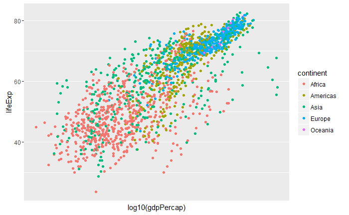

```r
ggplot(gapminder, aes(x = log10(gdpPercap), y = lifeExp)) +
  geom_point() + scale_x_log10() + geom_point(aes(color = continent))
```

```r
print(gapminder)
```

| country | continent | year | lifeExp | pop | gdpPercap |
| --- | --- | --- | --- | --- | --- |
| Afghanistan | Asia | 1952 | 28.80100 | 8425333 | 779.4453 |
| Afghanistan | Asia | 1957 | 30.33200 | 9240934 | 820.8530 |
| Afghanistan | Asia | 1962 | 31.99700 | 10267083 | 853.1007 |
| Afghanistan | Asia | 1967 | 34.02000 | 11537966 | 836.1971 |
| Afghanistan | Asia | 1972 | 36.08800 | 13079460 | 739.9811 |
| Afghanistan | Asia | 1977 | 38.43800 | 14880372 | 786.1134 |
| Afghanistan | Asia | 1982 | 39.85400 | 12881816 | 978.0114 |
| Afghanistan | Asia | 1987 | 40.82200 | 13867957 | 852.3959 |
| Afghanistan | Asia | 1992 | 41.67400 | 16317921 | 649.3414 |
| Afghanistan | Asia | 1997 | 41.76300 | 22227415 | 635.3414 |

[output cut: 990 more lines]

```r
Americas <- sqldf("SELECT * FROM gapminder
                  WHERE continent='Asia' AND year = '2007' AND lifeExp > 75
                  ORDER BY lifeExp DESC")
print(Americas)
```

| country | continent | year | lifeExp | pop | gdpPercap |
| --- | --- | --- | --- | --- | --- |
| Japan | Asia | 2007 | 82.603 | 127467972 | 31656.07 |
| Hong Kong, China | Asia | 2007 | 82.208 | 6980412 | 39724.98 |
| Israel | Asia | 2007 | 80.745 | 6426679 | 25523.28 |
| Singapore | Asia | 2007 | 79.972 | 4553009 | 47143.18 |
| Korea, Rep. | Asia | 2007 | 78.623 | 49044790 | 23348.14 |
| Taiwan | Asia | 2007 | 78.400 | 23174294 | 28718.28 |
| Kuwait | Asia | 2007 | 77.588 | 2505559 | 47306.99 |
| Oman | Asia | 2007 | 75.640 | 3204897 | 22316.19 |
| Bahrain | Asia | 2007 | 75.635 | 708573 | 29796.05 |

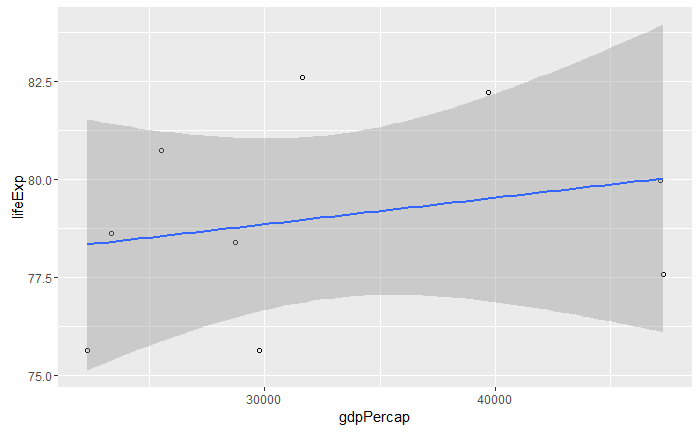

```r
ggplot(Americas, aes(x=gdpPercap, y=lifeExp)) +
    geom_point(shape=1) +    # Use hollow circles
    geom_smooth(method=lm)   # Add linear regression line
```

```r
                             #  (by default includes 95% confidence region)
```

4. Look at the nycflights13 data. Here the data file contains many files and can be used to merge substes of the data.

```r
head(airlines)
```

| carrier | name |
| --- | --- |
| 9E | Endeavor Air Inc. |
| AA | American Airlines Inc. |
| AS | Alaska Airlines Inc. |
| B6 | JetBlue Airways |
| DL | Delta Air Lines Inc. |
| EV | ExpressJet Airlines Inc. |

```r
head(flights)
```

| year | month | day | dep_time | sched_dep_time | dep_delay | arr_time | sched_arr_time | arr_delay | carrier | flight | tailnum | origin | dest | air_time | distance | hour | minute | time_hour |
| --- | --- | --- | --- | --- | --- | --- | --- | --- | --- | --- | --- | --- | --- | --- | --- | --- | --- | --- |
| 2013 | 1 | 1 | 517 | 515 | 2 | 830 | 819 | 11 | UA | 1545 | N14228 | EWR | IAH | 227 | 1400 | 5 | 15 | 2013-01-01 05:00:00 |
| 2013 | 1 | 1 | 533 | 529 | 4 | 850 | 830 | 20 | UA | 1714 | N24211 | LGA | IAH | 227 | 1416 | 5 | 29 | 2013-01-01 05:00:00 |
| 2013 | 1 | 1 | 542 | 540 | 2 | 923 | 850 | 33 | AA | 1141 | N619AA | JFK | MIA | 160 | 1089 | 5 | 40 | 2013-01-01 05:00:00 |
| 2013 | 1 | 1 | 544 | 545 | -1 | 1004 | 1022 | -18 | B6 | 725 | N804JB | JFK | BQN | 183 | 1576 | 5 | 45 | 2013-01-01 05:00:00 |
| 2013 | 1 | 1 | 554 | 600 | -6 | 812 | 837 | -25 | DL | 461 | N668DN | LGA | ATL | 116 | 762 | 6 | 0 | 2013-01-01 06:00:00 |
| 2013 | 1 | 1 | 554 | 558 | -4 | 740 | 728 | 12 | UA | 1696 | N39463 | EWR | ORD | 150 | 719 | 5 | 58 | 2013-01-01 05:00:00 |

```r
head(planes)
```

| tailnum | year | type | manufacturer | model | engines | seats | speed | engine |
| --- | --- | --- | --- | --- | --- | --- | --- | --- |
| N10156 | 2004 | Fixed wing multi engine | EMBRAER | EMB-145XR | 2 | 55 | NA | Turbo-fan |
| N102UW | 1998 | Fixed wing multi engine | AIRBUS INDUSTRIE | A320-214 | 2 | 182 | NA | Turbo-fan |
| N103US | 1999 | Fixed wing multi engine | AIRBUS INDUSTRIE | A320-214 | 2 | 182 | NA | Turbo-fan |
| N104UW | 1999 | Fixed wing multi engine | AIRBUS INDUSTRIE | A320-214 | 2 | 182 | NA | Turbo-fan |
| N10575 | 2002 | Fixed wing multi engine | EMBRAER | EMB-145LR | 2 | 55 | NA | Turbo-fan |
| N105UW | 1999 | Fixed wing multi engine | AIRBUS INDUSTRIE | A320-214 | 2 | 182 | NA | Turbo-fan |

```r
head(weather)
```

| origin | year | month | day | hour | temp | dewp | humid | wind_dir | wind_speed | wind_gust | precip | pressure | visib | time_hour |
| --- | --- | --- | --- | --- | --- | --- | --- | --- | --- | --- | --- | --- | --- | --- |
| EWR | 2013 | 1 | 1 | 0 | 37.04 | 21.92 | 53.97 | 230 | 10.35702 | 11.91865 | 0 | 1013.9 | 10 | 2012-12-31 16:00:00 |
| EWR | 2013 | 1 | 1 | 1 | 37.04 | 21.92 | 53.97 | 230 | 13.80936 | 15.89154 | 0 | 1013.0 | 10 | 2012-12-31 17:00:00 |
| EWR | 2013 | 1 | 1 | 2 | 37.94 | 21.92 | 52.09 | 230 | 12.65858 | 14.56724 | 0 | 1012.6 | 10 | 2012-12-31 18:00:00 |
| EWR | 2013 | 1 | 1 | 3 | 37.94 | 23.00 | 54.51 | 230 | 13.80936 | 15.89154 | 0 | 1012.7 | 10 | 2012-12-31 19:00:00 |
| EWR | 2013 | 1 | 1 | 4 | 37.94 | 24.08 | 57.04 | 240 | 14.96014 | 17.21583 | 0 | 1012.8 | 10 | 2012-12-31 20:00:00 |
| EWR | 2013 | 1 | 1 | 6 | 39.02 | 26.06 | 59.37 | 270 | 10.35702 | 11.91865 | 0 | 1012.0 | 10 | 2012-12-31 22:00:00 |

Some merges:

1. Add the planes data to the flights data table by tail number.

```r
flights.plane <- sqldf("SELECT flights.year,flights.flight,flights.tailnum,flights.carrier,flights.distance,
                       flights.air_time,planes.type,planes.model,planes.engines
                       FROM flights LEFT JOIN planes ON flights.tailnum = planes.tailnum")
print(flights.plane)
```

| year | flight | tailnum | carrier | distance | air_time | type | model | engines |
| --- | --- | --- | --- | --- | --- | --- | --- | --- |
| 2013 | 1545 | N14228 | UA | 1400 | 227 | Fixed wing multi engine | 737-824 | 2 |
| 2013 | 1714 | N24211 | UA | 1416 | 227 | Fixed wing multi engine | 737-824 | 2 |
| 2013 | 1141 | N619AA | AA | 1089 | 160 | Fixed wing multi engine | 757-223 | 2 |
| 2013 | 725 | N804JB | B6 | 1576 | 183 | Fixed wing multi engine | A320-232 | 2 |
| 2013 | 461 | N668DN | DL | 762 | 116 | Fixed wing multi engine | 757-232 | 2 |
| 2013 | 1696 | N39463 | UA | 719 | 150 | Fixed wing multi engine | 737-924ER | 2 |
| 2013 | 507 | N516JB | B6 | 1065 | 158 | Fixed wing multi engine | A320-232 | 2 |
| 2013 | 5708 | N829AS | EV | 229 | 53 | Fixed wing multi engine | CL-600-2B19 | 2 |
| 2013 | 79 | N593JB | B6 | 944 | 140 | Fixed wing multi engine | A320-232 | 2 |
| 2013 | 301 | N3ALAA | AA | 733 | 138 | NA | NA | NA |

[output cut: 990 more lines]

```r
flights_plane <- sqldf("SELECT flights.year,flights.flight,flights.tailnum,flights.carrier,flights.distance,
                       flights.air_time,planes.type,planes.model,planes.engines
                       FROM flights LEFT JOIN planes ON flights.tailnum = planes.tailnum
                       ORDER BY flights.distance DESC")
print(flights_plane)
```

| year | flight | tailnum | carrier | distance | air_time | type | model | engines |
| --- | --- | --- | --- | --- | --- | --- | --- | --- |
| 2013 | 51 | N380HA | HA | 4983 | 659 | Fixed wing multi engine | A330-243 | 2 |
| 2013 | 51 | N380HA | HA | 4983 | 638 | Fixed wing multi engine | A330-243 | 2 |
| 2013 | 51 | N380HA | HA | 4983 | 616 | Fixed wing multi engine | A330-243 | 2 |
| 2013 | 51 | N384HA | HA | 4983 | 639 | Fixed wing multi engine | A330-243 | 2 |
| 2013 | 51 | N381HA | HA | 4983 | 635 | Fixed wing multi engine | A330-243 | 2 |
| 2013 | 51 | N385HA | HA | 4983 | 611 | Fixed wing multi engine | A330-243 | 2 |
| 2013 | 51 | N385HA | HA | 4983 | 612 | Fixed wing multi engine | A330-243 | 2 |
| 2013 | 51 | N389HA | HA | 4983 | 645 | Fixed wing multi engine | A330-243 | 2 |
| 2013 | 51 | N384HA | HA | 4983 | 640 | Fixed wing multi engine | A330-243 | 2 |
| 2013 | 51 | N388HA | HA | 4983 | 633 | Fixed wing multi engine | A330-243 | 2 |

[output cut: 990 more lines]

2. Add the name of the carrier to the planes data table.
3. Add the information about the planes to the flights data table. Join the planes data to the flights data on tailnum.

```r
flights_plane_name <- sqldf("SELECT flights_plane.carrier, airlines.name,
                       flights_plane.year,flights_plane.flight,flights_plane.tailnum,
                       flights_plane.distance, flights_plane.air_time,flights_plane.type,
                       flights_plane.model,flights_plane.engines
                       FROM flights_plane LEFT JOIN airlines ON flights_plane.carrier = airlines.carrier")
print(flights_plane_name)
```

| carrier | name | year | flight | tailnum | distance | air_time | type | model | engines |
| --- | --- | --- | --- | --- | --- | --- | --- | --- | --- |
| HA | Hawaiian Airlines Inc. | 2013 | 51 | N380HA | 4983 | 659 | Fixed wing multi engine | A330-243 | 2 |
| HA | Hawaiian Airlines Inc. | 2013 | 51 | N380HA | 4983 | 638 | Fixed wing multi engine | A330-243 | 2 |
| HA | Hawaiian Airlines Inc. | 2013 | 51 | N380HA | 4983 | 616 | Fixed wing multi engine | A330-243 | 2 |
| HA | Hawaiian Airlines Inc. | 2013 | 51 | N384HA | 4983 | 639 | Fixed wing multi engine | A330-243 | 2 |
| HA | Hawaiian Airlines Inc. | 2013 | 51 | N381HA | 4983 | 635 | Fixed wing multi engine | A330-243 | 2 |
| HA | Hawaiian Airlines Inc. | 2013 | 51 | N385HA | 4983 | 611 | Fixed wing multi engine | A330-243 | 2 |
| HA | Hawaiian Airlines Inc. | 2013 | 51 | N385HA | 4983 | 612 | Fixed wing multi engine | A330-243 | 2 |
| HA | Hawaiian Airlines Inc. | 2013 | 51 | N389HA | 4983 | 645 | Fixed wing multi engine | A330-243 | 2 |
| HA | Hawaiian Airlines Inc. | 2013 | 51 | N384HA | 4983 | 640 | Fixed wing multi engine | A330-243 | 2 |
| HA | Hawaiian Airlines Inc. | 2013 | 51 | N388HA | 4983 | 633 | Fixed wing multi engine | A330-243 | 2 |

[output cut: 990 more lines]

Save the file to an sqlite dataset.

```r
library(dplyr)
nycflights13_sqlite(path = "C:/Users/Eric A. Suess/Documents")
```

```
src:  sqlite 3.8.6 [C:/Users/Eric A. Suess/Documents/nycflights13.sqlite]
tbls: airlines, airports, flights, planes, sqlite_stat1, weather
```

Another topic.

Interesting document about loading and saving data files in different data formats.

https://cran.rstudio.com/web/packages/saves/vignettes/saves.pdf